# 10. Data Wangling & Cleaning

We will use a case study approach for the class to understand steps before building machine learning models to ensure the data is robust for making prodections.

This problem statement from an **online education platform** where we’ll look at factors that help us select the most promising leads, i.e. the leads that are most likely to convert into paying customers.

Our ultimate goal- We shall use the data from previous leads who did convert to a customer and many who did not to build a model that we can use to score incoming leads for preferential retargeting.

The data dictionary for the data set is [here](https://drive.google.com/file/d/11k24B6GNnurpFJobZwHomEGrYmjsWRsy/view?usp=sharing)

```python
import pandas as pd
import numpy as np
import matplotlib.pyplot as plt
import seaborn as sns
```

# 10.1 Load data and High level review

```python
df= pd.read_csv('https://raw.githubusercontent.com/sdhar-pycourse/py-datascience-biz/main/practise-datasets/Leads.csv', index_col=0)
```

```python
df.shape
```

```
(9240, 36)
```

```python
for i,c in enumerate(df.columns):
  print(i,c)
```

```
0 Lead Number
1 Lead Origin
2 Lead Source
3 Do Not Email
4 Do Not Call
5 Converted
6 TotalVisits
7 Total Time Spent on Website
8 Page Views Per Visit
9 Last Activity
10 Country
11 Specialization
12 How did you hear about X Education
13 What is your current occupation
14 What matters most to you in choosing a course
```

[output cut: 21 more lines]

```python
df.columns
```

```
Index(['Lead Number', 'Lead Origin', 'Lead Source', 'Do Not Email',
       'Do Not Call', 'Converted', 'TotalVisits',
       'Total Time Spent on Website', 'Page Views Per Visit', 'Last Activity',
       'Country', 'Specialization', 'How did you hear about X Education',
       'What is your current occupation',
       'What matters most to you in choosing a course', 'Search', 'Magazine',
       'Newspaper Article', 'X Education Forums', 'Newspaper',
       'Digital Advertisement', 'Through Recommendations',
       'Receive More Updates About Our Courses', 'Tags', 'Lead Quality',
       'Update me on Supply Chain Content', 'Get updates on DM Content',
       'Lead Profile', 'City', 'Asymmetrique Activity Index',
       'Asymmetrique Profile Index', 'Asymmetrique Activity Score',
       'Asymmetrique Profile Score',
       'I agree to pay the amount through cheque',
       'A free copy of Mastering The Interview', 'Last Notable Activity'],
      dtype='object')
```

## 10.1.1 Assign 'handles'

```python
handle= ['prospsid', 'leadnum', 'origin', 'dne', 'dnc', 'target', 'totviz', 'tos', 'pageviz', 'lastact', 'country', 'splz',
         'leadsrc', 'curoccp', 'reason', 'srch', 'mag', 'newsart', 'edforum', 'newsad', 'digitalad', 'reco', 'updates', 'tag', 'leadquality', 'supchncont',
         'dmcontent', 'leadprofile', 'city', 'asymactidx', 'asymprofidx', 'asymactscr', 'asymprofscr', 'chkpay', 'freecp', 'lastnotact']
```

```python
column_map= dict(zip(df.columns, handle))
```

```python
column_map
```

```
{'A free copy of Mastering The Interview': 'freecp',
 'Asymmetrique Activity Index': 'asymactidx',
 'Asymmetrique Activity Score': 'asymactscr',
 'Asymmetrique Profile Index': 'asymprofidx',
 'Asymmetrique Profile Score': 'asymprofscr',
 'City': 'city',
 'Converted': 'target',
 'Country': 'country',
 'Digital Advertisement': 'digitalad',
 'Do Not Call': 'dnc',
 'Do Not Email': 'dne',
 'Get updates on DM Content': 'dmcontent',
 'How did you hear about X Education': 'leadsrc',
 'I agree to pay the amount through cheque': 'chkpay',
 'Last Activity': 'lastact',
 'Last Notable Activity': 'lastnotact',
 'Lead Number': 'prospsid',
 'Lead Origin': 'leadnum',
 'Lead Profile': 'leadprofile',
 'Lead Quality': 'leadquality',
 'Lead Source': 'origin',
 'Magazine': 'mag',
 'Newspaper': 'newsad',
 'Newspaper Article': 'newsart',
 'Page Views Per Visit': 'pageviz',
 'Receive More Updates About Our Courses': 'updates',
 'Search': 'srch',
 'Specialization': 'splz',
 'Tags': 'tag',
 'Through Recommendations': 'reco',
 'Total Time Spent on Website': 'tos',
 'TotalVisits': 'totviz',
 'Update me on Supply Chain Content': 'supchncont',
 'What is your current occupation': 'curoccp',
 'What matters most to you in choosing a course': 'reason',
 'X Education Forums': 'edforum'}
```

```python
df.rename(columns=column_map, inplace=True)
```

```python
df.columns
```

```
Index(['prospsid', 'leadnum', 'origin', 'dne', 'dnc', 'target', 'totviz',
       'tos', 'pageviz', 'lastact', 'country', 'splz', 'leadsrc', 'curoccp',
       'reason', 'srch', 'mag', 'newsart', 'edforum', 'newsad', 'digitalad',
       'reco', 'updates', 'tag', 'leadquality', 'supchncont', 'dmcontent',
       'leadprofile', 'city', 'asymactidx', 'asymprofidx', 'asymactscr',
       'asymprofscr', 'chkpay', 'freecp', 'lastnotact'],
      dtype='object')
```

# 10.2 Review Target Variable

We have no idea what kind of variable it is...

```python
df.target.isnull().sum()
```

```
0
```

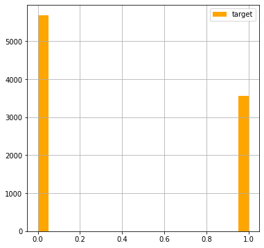

```python
df.target.hist(bins=20, figsize=(6,6), color= 'orange', legend=True)
```

# 10.3 Variable Types

```python
cat_vars= df.columns[df.dtypes== 'object'].tolist()
```

```python
cat_vars
```

```
['leadnum',
 'origin',
 'dne',
 'dnc',
 'lastact',
 'country',
 'splz',
 'leadsrc',
 'curoccp',
 'reason',
 'srch',
 'mag',
 'newsart',
 'edforum',
 'newsad',
 'digitalad',
 'reco',
 'updates',
 'tag',
 'leadquality',
 'supchncont',
 'dmcontent',
 'leadprofile',
 'city',
 'asymactidx',
 'asymprofidx',
 'chkpay',
 'freecp',
 'lastnotact']
```

```python
num_vars=df.columns[(df.dtypes!= 'object')].tolist()
```

```python
num_vars.pop(1)
```

```
'target'
```

```python
num_vars
```

```
['prospsid', 'totviz', 'tos', 'pageviz', 'asymactscr', 'asymprofscr']
```

## 10.3.1 Categorical Variables [Non-Numeric]

```python
df.loc[:,cat_vars].describe().T
```

|  | count | unique | top | freq |
| --- | --- | --- | --- | --- |
| leadnum | 9240 | 5 | Landing Page Submission | 4886 |
| origin | 9204 | 21 | Google | 2868 |
| dne | 9240 | 2 | No | 8506 |
| dnc | 9240 | 2 | No | 9238 |
| lastact | 9137 | 17 | Email Opened | 3437 |
| country | 6779 | 38 | India | 6492 |
| splz | 7802 | 19 | Select | 1942 |
| leadsrc | 7033 | 10 | Select | 5043 |
| curoccp | 6550 | 6 | Unemployed | 5600 |
| reason | 6531 | 3 | Better Career Prospects | 6528 |
| srch | 9240 | 2 | No | 9226 |
| mag | 9240 | 1 | No | 9240 |
| newsart | 9240 | 2 | No | 9238 |
| edforum | 9240 | 2 | No | 9239 |
| newsad | 9240 | 2 | No | 9239 |
| digitalad | 9240 | 2 | No | 9236 |
| reco | 9240 | 2 | No | 9233 |
| updates | 9240 | 1 | No | 9240 |
| tag | 5887 | 26 | Will revert after reading the email | 2072 |
| leadquality | 4473 | 5 | Might be | 1560 |
| supchncont | 9240 | 1 | No | 9240 |
| dmcontent | 9240 | 1 | No | 9240 |
| leadprofile | 6531 | 6 | Select | 4146 |
| city | 7820 | 7 | Mumbai | 3222 |
| asymactidx | 5022 | 3 | 02.Medium | 3839 |
| asymprofidx | 5022 | 3 | 02.Medium | 2788 |
| chkpay | 9240 | 1 | No | 9240 |
| freecp | 9240 | 2 | No | 6352 |
| lastnotact | 9240 | 16 | Modified | 3407 |

## 10.3.2 Numeric Variables

```python
df.loc[:,num_vars].describe()
```

|  | prospsid | totviz | tos | pageviz | asymactscr | asymprofscr |
| --- | --- | --- | --- | --- | --- | --- |
| count | 9240.000000 | 9103.000000 | 9240.000000 | 9103.000000 | 5022.000000 | 5022.000000 |
| mean | 617188.435606 | 3.445238 | 487.698268 | 2.362820 | 14.306252 | 16.344883 |
| std | 23405.995698 | 4.854853 | 548.021466 | 2.161418 | 1.386694 | 1.811395 |
| min | 579533.000000 | 0.000000 | 0.000000 | 0.000000 | 7.000000 | 11.000000 |
| 25% | 596484.500000 | 1.000000 | 12.000000 | 1.000000 | 14.000000 | 15.000000 |
| 50% | 615479.000000 | 3.000000 | 248.000000 | 2.000000 | 14.000000 | 16.000000 |
| 75% | 637387.250000 | 5.000000 | 936.000000 | 3.000000 | 15.000000 | 18.000000 |
| max | 660737.000000 | 251.000000 | 2272.000000 | 55.000000 | 18.000000 | 20.000000 |

# 10.4 Cleaning Numeric Fields

There is little difference as to how Ratio & Interval variables usually are cleaned.

Some of the integers that a are 1/0 are nominal variables

## 10.4.1 `totviz`

The total number of visits made by the customer on the website.

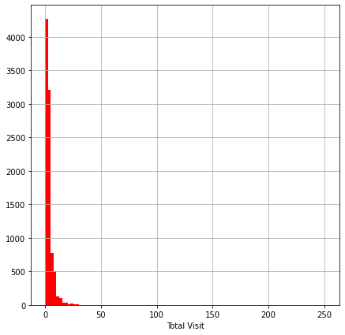

```python
df.totviz.hist(grid=True, bins=100, figsize=(7,7), color='red')
plt.xlabel('Total Visit')
```

```python
df.totviz.describe(percentiles=[.05,.25,.50,.75,.95])
```

```
count    9103.000000
mean        3.445238
std         4.854853
min         0.000000
5%          0.000000
25%         1.000000
50%         3.000000
75%         5.000000
95%        10.000000
max       251.000000
Name: totviz, dtype: float64
```

### 10.4.1.1 `Null` treatment of Numeric Values

- Use your intution to figure out why the value is missing. One of the most important questions you can ask yourself to help figure this out is this:

> Is this value missing because it wasn't recorded or because it doesn't exist?
- For a small % of rows that may have a value missing we choose to impute it with mean or median
- Small is a relative term- depending on the variability of the variables it may range up to 30-40% of data
- If the % is large and imputing a single value may impact predictive power and hence should be dropped

```python
df.totviz.describe()
```

```
count    9103.000000
mean        3.445238
std         4.854853
min         0.000000
25%         1.000000
50%         3.000000
75%         5.000000
max       251.000000
Name: totviz, dtype: float64
```

```python
100*df.totviz.isnull().sum()/ len(df)
```

```
1.4826839826839826
```

```python
df.totviz.fillna(df.totviz.median(), axis=0, inplace=True)
```

```python
df.totviz.fillna(df.totviz.median(), axis=0, inplace= True)
```

```python
100*df.totviz.isnull().sum()/ len(df)
```

```
0.0
```

```python
df.totviz.describe()
```

```
count    9240.000000
mean        3.438636
std         4.819024
min         0.000000
25%         1.000000
50%         3.000000
75%         5.000000
max       251.000000
Name: totviz, dtype: float64
```

### 10.4.1.2 Dropping all records with null values

```python
df1= df.copy(deep=True)
df1.isnull().sum()
```

```
prospsid          0
leadnum           0
origin           36
dne               0
dnc               0
target            0
totviz            0
tos               0
pageviz         137
lastact         103
country        2461
splz           1438
leadsrc        2207
curoccp        2690
reason         2709
srch              0
mag               0
newsart           0
edforum           0
newsad            0
digitalad         0
reco              0
updates           0
tag            3353
leadquality    4767
supchncont        0
dmcontent         0
leadprofile    2709
city           1420
asymactidx     4218
asymprofidx    4218
asymactscr     4218
asymprofscr    4218
chkpay            0
freecp            0
lastnotact        0
dtype: int64
```

```python
df1.dropna(inplace=True)
```

```python
df1.isnull().sum()
```

```
prospsid       0
leadnum        0
origin         0
dne            0
dnc            0
target         0
totviz         0
tos            0
pageviz        0
lastact        0
country        0
splz           0
leadsrc        0
curoccp        0
reason         0
srch           0
mag            0
newsart        0
edforum        0
newsad         0
digitalad      0
reco           0
updates        0
tag            0
leadquality    0
supchncont     0
dmcontent      0
leadprofile    0
city           0
asymactidx     0
asymprofidx    0
asymactscr     0
asymprofscr    0
chkpay         0
freecp         0
lastnotact     0
dtype: int64
```

```python
df1.shape
```

```
(1943, 36)
```

### 10.4.1.3 Outlier treatment of Numeric Values

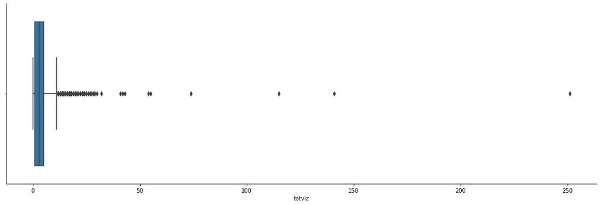

```python
sns.catplot(data=df, x='totviz', kind= 'box', orient='h', aspect=3)
```

- Floor with 5th or 25th Percentile Value
- Cap with 95th or 75th percentile value

Depends on usage and practice. What is seen and expected in reality?

What you want to understand is what are generally acceptable ranges of values

```python
p5=df.totviz.describe(percentiles=[.05,.25,.50,.75,.95]).loc['5%']
p95= df.totviz.describe(percentiles=[.05,.25,.50,.75,.95]).loc['95%']
```

```python
df.totviz.describe(percentiles=[.05,.25,.50,.75,.95]).loc['95%']
```

```
10.0
```

```python
df["totviz"] = np.where(df["totviz"] <p5, p5,df['totviz'])
df["totviz"] = np.where(df["totviz"] >p95, p95,df['totviz'])
```

```python
df["totviz"] <p5
```

```
Prospect ID
7927b2df-8bba-4d29-b9a2-b6e0beafe620    False
2a272436-5132-4136-86fa-dcc88c88f482    False
8cc8c611-a219-4f35-ad23-fdfd2656bd8a    False
0cc2df48-7cf4-4e39-9de9-19797f9b38cc    False
3256f628-e534-4826-9d63-4a8b88782852    False
                                        ...
19d6451e-fcd6-407c-b83b-48e1af805ea9    False
82a7005b-7196-4d56-95ce-a79f937a158d    False
aac550fe-a586-452d-8d3c-f1b62c94e02c    False
5330a7d1-2f2b-4df4-85d6-64ca2f6b95b9    False
571b5c8e-a5b2-4d57-8574-f2ffb06fdeff    False
Name: totviz, Length: 9240, dtype: bool
```

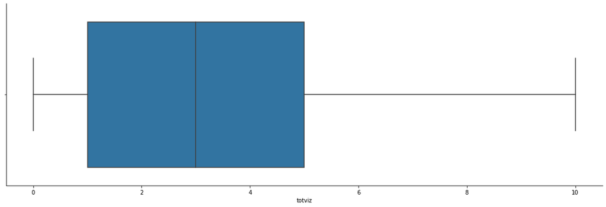

```python
sns.catplot(data=df, x='totviz', kind= 'box', orient='h', aspect=3)
```